# Wiki_Project

## Wikipedia Project Notebook

### Neha, Viki, and Hannah

#### Description:

Our topic of investigation is on the vandalism on women/gender/racial pages on Wikipedia:

1. What types of vandalism are present on those sites?  
   a. Language used  
   b. Editors who are doing the vandalism  
   c. Which sites have the most vandalism
2. What other editors are doing about the vandalism?

**10/24/2017**

Our group decided to begin our investigation by looking into vandalism into powerful female athletes of our generation. For the first step, we are going to be analyzing Serena Williams's Wikipedia page. We will analyze her page for edits made by date and by user. This will be important for looking for vandalism made on certain dates/events (when she made a controversial comment, won or lost a major event, got pregnant, etc.)

```python
import mwclient
import warnings
warnings.filterwarnings(action='ignore')
from mwclient import Site
from collections import defaultdict
from time import mktime
from datetime import datetime
from collections import Counter
import matplotlib.pyplot as plt
# the following line is used to make sure that the plots will show inline in the notebook
%matplotlib inline
import plotly.graph_objs as go
import plotly.plotly as py
import copy
```

```python
site = Site('en.wikipedia.org')

swp = site.pages['Serena Williams']

revisions = [rev for rev in swp.revisions()]
len(revisions)
```

```
14013
```

```python
try:
    import cPickle as pickle
except:
    import pickle
#write as bytes to json file
with open("wellesleycollegerevisions.pck", 'wb') as pckFile:
    pickle.dump(revisions, pckFile)

#load and check length
revisionsList = pickle.load(open("wellesleycollegerevisions.pck", 'rb'))
len(revisionsList)
```

```
14013
```

Extract data about timestamps

```python
def createDateTime(rev):
    return datetime.fromtimestamp(mktime(rev['timestamp']))
```

Extract data about users

```python
users = []
timestamps = []
for r in revisions:
    if 'user' in r:
        users.append(r['user'])
        timestamps.append(createDateTime(r))

usersDct = Counter(users)
top_ten_users = usersDct.most_common(10)
```

Make a histogram with the timestamps showing distribution over years

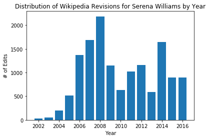

```python
def yearHistogram(allYearsCount, title):
    years = sorted(allYearsCount.keys())
    freq_years = [allYearsCount[y] for y in years]
    plt.bar([y-1 for y in years], freq_years)
    #plt.xticks(years)
    plt.xlabel("Year")
    plt.ylabel("# of Edits")
    plt.title(title)
    plt.show()

allYears = [ts.year for ts in timestamps]
allYearsCount = Counter(allYears)

yearHistogram(allYearsCount, "Distribution of Wikipedia Revisions for Serena Williams by Year")
```

Make a heatmap showing distribution of edits by user according to year

```python
def userHeatMap(users, top_users, timestamps, years, title):
    user_time = zip(users, timestamps)
    #create a dict of dicts
    #outer dict has user keys and inner dict has year keys and edit values
    year_dict = {y:0 for y in years}
    #default if user hasn't edited that year will include the year with value 0
    user_dict = defaultdict(lambda:dict(year_dict))
    for u in user_time:
        usr, ts = u
        user_dict[usr][ts] += 1

    y_vals = list(top_users)
    x_vals = sorted(years)
    z_vals = []
    for y in y_vals:
        z = [user_dict[y][x] for x in x_vals]
        z_vals.append(z)

    data = [go.Heatmap(z = z_vals, x = x_vals, y = y_vals)]
    layout = go.Layout(
        title= title,
        xaxis = dict(ticks=''),
        yaxis = dict(ticks='' )
    )

    fig = go.Figure(data=data, layout=layout)
    py.iplot(fig, filename='serena_heatmap')

userHeatMap(users, top_ten_users,allYears, list(allYearsCount.keys()), 'Serena Williams User and Year Edit HeatMap')
```

[output not shown]